# twitter

```python
import numpy as np
import pandas as pd
import matplotlib.pyplot as plt
from sklearn.svm import SVC
from sklearn.model_selection import train_test_split
from sklearn.metrics import make_scorer
from sklearn.metrics import accuracy_score
from sklearn.model_selection import ShuffleSplit
from sklearn.metrics import f1_score
```

```python
tweets = pd.read_csv('Tweets.csv')
tweets.head(5)
```

|  | tweet_id | airline_sentiment | airline_sentiment_confidence | negativereason | negativereason_confidence | airline | airline_sentiment_gold | name | negativereason_gold | retweet_count | text | tweet_coord | tweet_created | tweet_location | user_timezone |
| --- | --- | --- | --- | --- | --- | --- | --- | --- | --- | --- | --- | --- | --- | --- | --- |
| 0 | 570306133677760513 | neutral | 1.0000 | NaN | NaN | Virgin America | NaN | cairdin | NaN | 0 | @VirginAmerica What @dhepburn said. | NaN | 2015-02-24 11:35:52 -0800 | NaN | Eastern Time (US & Canada) |
| 1 | 570301130888122368 | positive | 0.3486 | NaN | 0.0000 | Virgin America | NaN | jnardino | NaN | 0 | @VirginAmerica plus you've added commercials t... | NaN | 2015-02-24 11:15:59 -0800 | NaN | Pacific Time (US & Canada) |
| 2 | 570301083672813571 | neutral | 0.6837 | NaN | NaN | Virgin America | NaN | yvonnalynn | NaN | 0 | @VirginAmerica I didn't today... Must mean I n... | NaN | 2015-02-24 11:15:48 -0800 | Lets Play | Central Time (US & Canada) |
| 3 | 570301031407624196 | negative | 1.0000 | Bad Flight | 0.7033 | Virgin America | NaN | jnardino | NaN | 0 | @VirginAmerica it's really aggressive to blast... | NaN | 2015-02-24 11:15:36 -0800 | NaN | Pacific Time (US & Canada) |
| 4 | 570300817074462722 | negative | 1.0000 | Can't Tell | 1.0000 | Virgin America | NaN | jnardino | NaN | 0 | @VirginAmerica and it's a really big bad thing... | NaN | 2015-02-24 11:14:45 -0800 | NaN | Pacific Time (US & Canada) |

```python
display(tweets.describe())
```

|  | tweet_id | airline_sentiment_confidence | negativereason_confidence | retweet_count |
| --- | --- | --- | --- | --- |
| count | 1.464000e+04 | 14640.000000 | 10522.000000 | 14640.000000 |
| mean | 5.692184e+17 | 0.900169 | 0.638298 | 0.082650 |
| std | 7.791112e+14 | 0.162830 | 0.330440 | 0.745778 |
| min | 5.675883e+17 | 0.335000 | 0.000000 | 0.000000 |
| 25% | 5.685592e+17 | 0.692300 | 0.360600 | 0.000000 |
| 50% | 5.694779e+17 | 1.000000 | 0.670600 | 0.000000 |
| 75% | 5.698905e+17 | 1.000000 | 1.000000 | 0.000000 |
| max | 5.703106e+17 | 1.000000 | 1.000000 | 44.000000 |

```python
most_users=tweets.groupby('name')['tweet_id'].nunique().sort_values(ascending=False).head(10)
```

```python
most_users_data=tweets[tweets['name'].isin( most_users.index.values)]
```

```
[1, 2]
```

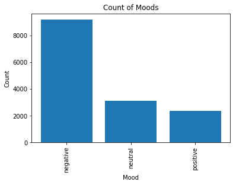

```python
plt.bar([1,2,3],tweets['airline_sentiment'].value_counts())
plt.xticks([1,2,3],tweets['airline_sentiment'].value_counts().index.values,rotation=90)
plt.ylabel('Count')
plt.xlabel('Mood')
plt.title('Count of Moods')
tweets['name'].value_counts().index.values
tweets['name'].index.values.tolist()[1:3]
```

So the negative mood is very high comparing to the other moodes that makes sense since we trying to detect the negative tweets only.

```
Text(0.5,1,'number of tweets for the top 10 users')
```

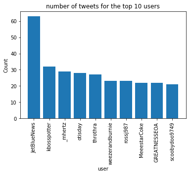

```python
plt.bar(np.arange(1,11),tweets['name'].value_counts()[0:10])
plt.xticks(np.arange(1,11),tweets['name'].value_counts().index.values[0:10],rotation=90)
plt.ylabel('Count')
plt.xlabel('user')
plt.title('number of tweets for the top 10 users')
```

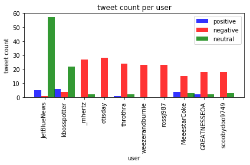

```python
positive=np.zeros(10)
negative=np.zeros(10)
neutral=np.zeros(10)
topusers=tweets['name'].value_counts().index.values
for i in range(0,10):
    tweets1=tweets[tweets['name']==topusers[i]]
    temp=tweets1['airline_sentiment'].value_counts().index.values
    for j in range(len(temp)):
        if temp[j]=='neutral':
            neutral[i]=tweets1['airline_sentiment'].value_counts()[j]
        elif temp[j]=='positive':
                positive[i]=tweets1['airline_sentiment'].value_counts()[j]
        else:
            negative[i]=tweets1['airline_sentiment'].value_counts()[j]
fig, ax = plt.subplots()
index = np.arange(10)
bar_width = 0.35
opacity = 0.8

rects1 = plt.bar(index, positive, bar_width,
alpha=opacity,
color='b',
label='positive')
rects2 = plt.bar(index + bar_width, negative, bar_width,
alpha=opacity,
color='r',
label='negative')
rects2 = plt.bar(index + 2*bar_width, neutral, bar_width,
alpha=opacity,
color='g',
label='neutral')

plt.xlabel('user')
plt.ylabel('tweet count')
plt.title('tweet count per user')

plt.xticks(index + bar_width, topusers[0:10],rotation=90)
plt.legend()

plt.tight_layout()
plt.show()
```

so for almost all users they have more negative tweets than thier positive and neutral ,but for 2 users with the most tweets they have much more positive and neutral tweets compared to the negative ,that's make sense because it seem they like flying too much that's why they did alot ,so it seems that those people will compaline only when there's too much negative incidences in the flight.

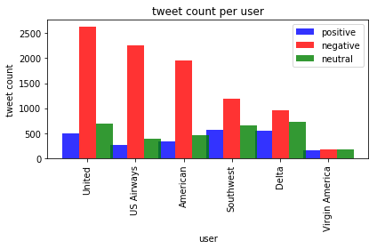

```
array(['United', 'US Airways', 'American', 'Southwest', 'Delta',
       'Virgin America'], dtype=object)
```

```python
airlines=tweets['airline'].value_counts().index.values
positive=np.zeros(len(airlines))
negative=np.zeros(len(airlines))
neutral=np.zeros(len(airlines))
for i in range(0,len(airlines)):
    tweets1=tweets[tweets['airline']==airlines[i]]
    temp=tweets1['airline_sentiment'].value_counts().index.values
    for j in range(len(temp)):
        if temp[j]=='neutral':
            neutral[i]=tweets1['airline_sentiment'].value_counts()[j]
        elif temp[j]=='positive':
                positive[i]=tweets1['airline_sentiment'].value_counts()[j]
        else:
            negative[i]=tweets1['airline_sentiment'].value_counts()[j]

fig, ax = plt.subplots()
index = np.arange(len(airlines))
bar_width = 0.35
opacity = 0.8

rects1 = plt.bar(index, positive, bar_width,
alpha=opacity,
color='b',
label='positive')
rects2 = plt.bar(index + bar_width, negative, bar_width,
alpha=opacity,
color='r',
label='negative')
rects2 = plt.bar(index + 2*bar_width, neutral, bar_width,
alpha=opacity,
color='g',
label='neutral')

plt.xlabel('user')
plt.ylabel('tweet count')
plt.title('tweet count per user')

plt.xticks(index + bar_width, airlines[0:len(airlines)+1],rotation=90)
plt.legend()

plt.tight_layout()
plt.show()
airlines
```

```
['Customer Service Issue' 'Late Flight' "Can't Tell" 'Cancelled Flight'
 'Lost Luggage' 'Bad Flight' 'Flight Booking Problems'
 'Flight Attendant Complaints' 'longlines' 'Damaged Luggage']
```

```
Text(0.5,1,'tweet count per user')
```

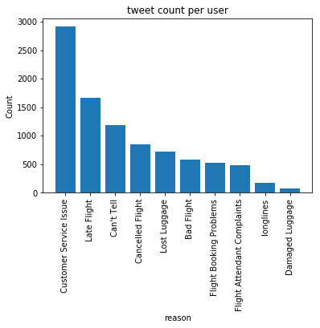

```python
reasons=tweets['negativereason'].value_counts()
print(reasons.index.values)
plt.bar(np.arange(1,len(reasons)+1),reasons)
plt.xticks(np.arange(1,len(reasons)+1),reasons.index.values,rotation=90)
plt.ylabel('Count')
plt.xlabel('reason')
plt.title('tweet count per user')
```

so it seems that customer service is the most important issue and then the late flight.

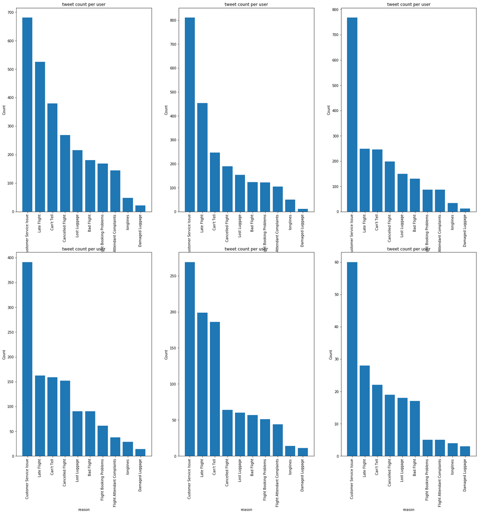

```python
airlines=tweets['airline'].value_counts().index.values
plt.figure(1,figsize=(24, 24))
i=231
for airline in airlines :
    tweets1=tweets[tweets['airline']==airline]
    reasons1=tweets1['negativereason'].value_counts()
    plt.subplot(i)
    i=i+1
    plt.bar(np.arange(1,len(reasons1)+1),reasons1)
    plt.xticks(np.arange(1,len(reasons1)+1),reasons.index.values,rotation=90)
    plt.ylabel('Count')
    plt.xlabel('reason')
    plt.title('tweet count per user')
```

# Now we will try to analys the tweet text.

We will get the most common words in the negative tweets and in the not negative tweets (positive and neutral), we focus on the negative since it's the main issue to analys negative tweets.

For negative tweets:

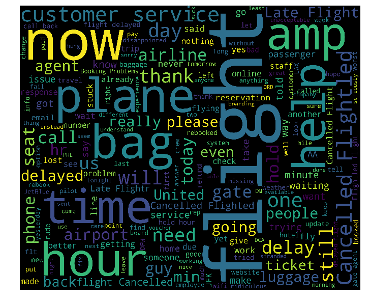

```python
from wordcloud import WordCloud,STOPWORDS
negative_tweets=tweets[tweets['airline_sentiment']=='negative']
words = ' '.join(negative_tweets['text'])
cleaned_word = " ".join([word for word in words.split()
                            if 'http' not in word
                                and not word.startswith('@')
                                and word != 'RT'
                            ])
wordcloud = WordCloud(stopwords=STOPWORDS,
                      background_color='black',
                      width=3000,
                      height=2500
                     ).generate(cleaned_word)
plt.figure(1,figsize=(12, 12))
plt.imshow(wordcloud)
plt.axis('off')
plt.show()
```

for not negative tweets:

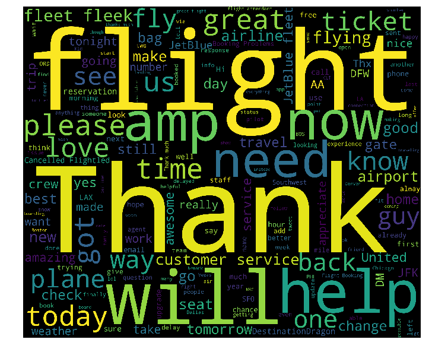

```python
positive_tweets=tweets[tweets['airline_sentiment']!='negative']
words = ' '.join(positive_tweets['text'])
cleaned_word = " ".join([word for word in words.split()
                            if 'http' not in word
                                and not word.startswith('@')
                                and word != 'RT'
                            ])
wordcloud = WordCloud(stopwords=STOPWORDS,
                      background_color='black',
                      width=3000,
                      height=2500
                     ).generate(cleaned_word)
plt.figure(1,figsize=(12, 12))
plt.imshow(wordcloud)
plt.axis('off')
plt.show()
```

We found that words like plane,bag,time and hour and mostly common in negative tweets and words like thank and wellare mostly common in other tweets and words like flight, now and help are very common in all tweets.

now since there's too much common words we can use simlarity engines like cosian simlarity.

first before training our model we need to clean the data by removing stopwords and most common words in all tweets.

# Removing stopwords:

```python
import re
import nltk
from nltk.corpus import stopwords
x=[]
for tweet in tweets['text']:
    letters_only = re.sub("[^a-zA-Z]", " ",tweet)
    words = letters_only.lower().split()
    stops = set(stopwords.words("english"))
    meaningful_words = [w for w in words if not w in stops]
    x.append(" ".join( meaningful_words ))
```

# Removing most Common words:

```python
X=[item.replace('now', '').replace('will', '').replace('need', '').replace('thank', '').replace('flight', '')
.replace('help', '').replace('amp', '').replace('please', '') for item in x]
y=tweets['airline_sentiment'].apply(lambda item: 0 if item=='negative' else 1)
```

we will use CountVectorizer to extract features since it provides a simple way to both tokenize a collection of text documents and build a vocabulary of known words, but also to encode new documents using that vocabulary.

```python
from sklearn.feature_extraction.text import CountVectorizer
v1 = CountVectorizer(analyzer = "word")
v2 = CountVectorizer(analyzer = "word")
train_x,test_x,train_y,test_y = train_test_split(X,y,test_size=0.2,random_state=42)
train_x= v1.fit_transform(train_x)
test_x=v1.transform(test_x)

train_x2,test_x2 = train_test_split(x,test_size=0.2,random_state=42)
train_x2= v2.fit_transform(train_x2)
test_x2=v2.transform(test_x2)
```

now we will build multiple models and train each modelt twice once on data before removing most coman words and another after removing them.

```python
classifiers=[]
acc1=[]
acc2=[]
```

# 1-Logistic Regression

```python
from sklearn.linear_model import LogisticRegression
model=LogisticRegression().fit(train_x,train_y)
pred=model.predict(test_x)
accuracy = accuracy_score(pred,test_y)
print('Accracy of model without removing common words',accuracy)

model2=LogisticRegression().fit(train_x2,train_y)
pred2=model2.predict(test_x2)
accuracy2 = accuracy_score(pred2,test_y)
print('Accracy of model after removing common words',accuracy2)
classifiers.append('LogisticRegression')
acc1.append(accuracy)
acc2.append(accuracy2)
```

```
Accracy of model without removing common words 0.8237704918032787
Accracy of model after removing common words 0.83025956284153
```

# 2-Ada Boost

```python
from sklearn.ensemble import AdaBoostClassifier
model=AdaBoostClassifier().fit(train_x,train_y)
pred=model.predict(test_x)
accuracy = accuracy_score(pred,test_y)
print('Accracy of model without removing common words',accuracy)

model2=AdaBoostClassifier().fit(train_x2,train_y)
pred2=model2.predict(test_x2)
accuracy2 = accuracy_score(pred2,test_y)
print('Accracy of model after removing common words',accuracy2)
classifiers.append('AdaBoost')
acc1.append(accuracy)
acc2.append(accuracy2)
```

```
Accracy of model without removing common words 0.7595628415300546
Accracy of model after removing common words 0.7855191256830601
```

# 3-DecisionTree

```python
from sklearn.tree import DecisionTreeClassifier
model=DecisionTreeClassifier().fit(train_x,train_y)
pred=model.predict(test_x)
accuracy = accuracy_score(pred,test_y)
print('Accracy of model without removing common words',accuracy)

model2=DecisionTreeClassifier().fit(train_x2,train_y)
pred2=model2.predict(test_x2)
accuracy2 = accuracy_score(pred2,test_y)
print('Accracy of model after removing common words',accuracy2)

classifiers.append('DecisionTree')
acc1.append(accuracy)
acc2.append(accuracy2)
```

```
Accracy of model without removing common words 0.755464480874317
Accracy of model after removing common words 0.7646857923497268
```

# 4-Random Fores

```python
from sklearn.ensemble import RandomForestClassifier
model=RandomForestClassifier(n_estimators=200).fit(train_x,train_y)
pred=model.predict(test_x)
accuracy = accuracy_score(pred,test_y)
print('Accracy of model without removing common words',accuracy)

model2=RandomForestClassifier(n_estimators=200).fit(train_x2,train_y)
pred2=model2.predict(test_x2)
accuracy2 = accuracy_score(pred2,test_y)
print('Accracy of model after removing common words',accuracy2)
classifiers.append('RandomForest')
acc1.append(accuracy)
acc2.append(accuracy2)
```

```
Accracy of model without removing common words 0.8049863387978142
Accracy of model after removing common words 0.8135245901639344
```

5-RBF SVM

```python
from sklearn.svm import SVC
model=SVC(kernel="rbf", C=0.1).fit(train_x,train_y)
pred=model.predict(test_x)
accuracy = accuracy_score(pred,test_y)
print('Accracy of model without removing common words',accuracy)

model2=SVC(kernel="rbf", C=0.1).fit(train_x2,train_y)
pred2=model2.predict(test_x2)
accuracy2 = accuracy_score(pred2,test_y)
print('Accracy of model after removing common words',accuracy2)
classifiers.append('RBF SVM')
acc1.append(accuracy)
acc2.append(accuracy2)
```

```
Accracy of model without removing common words 0.6451502732240437
Accracy of model after removing common words 0.6451502732240437
```

6-Linear SVM

```python
from sklearn.svm import SVC
model=SVC(kernel="linear", C=0.1).fit(train_x,train_y)
pred=model.predict(test_x)
accuracy = accuracy_score(pred,test_y)
print('Accracy of model without removing common words',accuracy)

model2=SVC(kernel="linear", C=0.1).fit(train_x2,train_y)
pred2=model2.predict(test_x2)
accuracy2 = accuracy_score(pred2,test_y)
print('Accracy of model after removing common words',accuracy2)
classifiers.append('Linear SVM')
acc1.append(accuracy)
acc2.append(accuracy2)
```

```
Accracy of model without removing common words 0.8172814207650273
Accracy of model after removing common words 0.8292349726775956
```

7-Poly SVM 2nd degree

```python
from sklearn.svm import SVC
model=SVC(kernel="poly",degree=2, C=0.1).fit(train_x,train_y)
pred=model.predict(test_x)
accuracy = accuracy_score(pred,test_y)
print('Accracy of model without removing common words',accuracy)

model2=SVC(kernel="poly",degree=2, C=0.1).fit(train_x2,train_y)
pred2=model2.predict(test_x2)
accuracy2 = accuracy_score(pred2,test_y)
print('Accracy of model after removing common words',accuracy2)
classifiers.append('Poly SVM 2nd degree')
acc1.append(accuracy)
acc2.append(accuracy2)
```

```
Accracy of model without removing common words 0.6451502732240437
Accracy of model after removing common words 0.6451502732240437
```

8- Poly SVM 3rd degree

```python
from sklearn.svm import SVC
model=SVC(kernel="poly",degree=3, C=0.1).fit(train_x,train_y)
pred=model.predict(test_x)
accuracy = accuracy_score(pred,test_y)
print('Accracy of model without removing common words',accuracy)

model2=SVC(kernel="poly",degree=3, C=0.1).fit(train_x2,train_y)
pred2=model2.predict(test_x2)
accuracy2 = accuracy_score(pred2,test_y)
print('Accracy of model after removing common words',accuracy2)
classifiers.append('Poly SVM 3rd degree')
acc1.append(accuracy)
acc2.append(accuracy2)
```

```
Accracy of model without removing common words 0.6451502732240437
Accracy of model after removing common words 0.6451502732240437
```

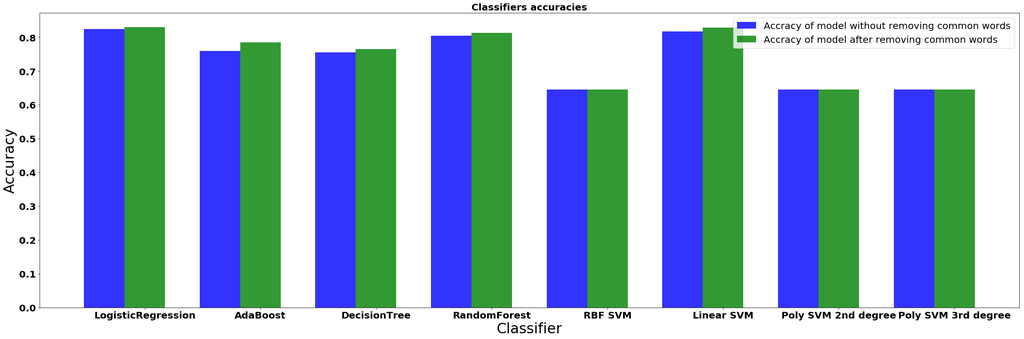

```python
fig, ax = plt.subplots(figsize=(30,10),)
index = np.arange(8)
bar_width = 0.35
opacity = 0.8

rects1 = plt.bar(index, acc1, bar_width,
alpha=opacity,
color='b',
label='Accracy of model without removing common words')

rects2 = plt.bar(index + bar_width, acc2, bar_width,
alpha=opacity,
color='g',
label='Accracy of model after removing common words')


plt.xlabel('Classifier', size=30)
plt.ylabel('Accuracy', size=30)
plt.title('Classifiers accuracies',fontweight="bold", size=20)

plt.xticks(index + bar_width, classifiers,rotation=0,fontweight="bold", size=20)
plt.yticks(fontweight="bold", size=20)
plt.legend(fontsize = 20)

plt.tight_layout()
plt.show()
```

It seems that the data is lineary sperated since Logistic Regression and Linear SVM have the highest accuracies with 83% and 82.9% respectivly and the polynomial and RBF have the worest accuracies.